# Problem Context

# Model 4 - Using GridSearchCV

Some important hyperparameters to look out for while optimizing neural networks are:

Type of Architecture

Number of Layers

Number of Neurons in a layer

Regularization hyperparameters

Learning Rate

Type of Optimizer

Dropout Rate

**We will use GridSearchCV to optimize two hyperparameters - Batch Size & Learning Rate.**

Model4 will be configured with the following:

- 7 layers - relu activation function for the hidden layer and sigmoid  
  activation for the output layer.
- Adam Optimizer
- Threshold will be determined using the ROC-AUC curve
- Both Dropout and BatchNormalization techniques will be utilized.

The neural network will be configured to take in a vector of length 13 as input. For each transaction, the final layer will output a probability.

```python
set_seed_and_clear_session()
```

```python
def create_model_v4(lr,batch_size):
    model_4 = Sequential()
    model_4.add(Dense(256,activation='relu',input_dim = X_train.shape[1]))
    model_4.add(Dropout(0.5))
    model_4.add(Dense(128,activation='relu'))
    model_4.add(Dropout(0.5))
    model_4.add(Dense(128,activation='relu'))
    model_4.add(BatchNormalization())
    model_4.add(Dense(64,activation='relu'))
    model_4.add(BatchNormalization())
    model_4.add(Dense(64,activation='relu'))
    model_4.add(Dropout(0.5))
    model_4.add(Dense(32,activation='relu'))
    model_4.add(Dense(1, activation='sigmoid'))

    #compile model
    optimizer = tf.keras.optimizers.Adam(learning_rate=lr)
    model_4.compile(optimizer = optimizer,loss = 'binary_crossentropy', metrics = ['accuracy'])
    return model_4
```

```python
keras_estimator = KerasClassifier(build_fn=create_model_v4, verbose=1)
# define the grid search parameters
param_grid = {
    'batch_size':[64,32, 128],
    "lr":[0.01,0.1,0.001],}

kfold_splits = 3
grid = GridSearchCV(estimator=keras_estimator,
                    verbose=1,
                    cv=kfold_splits,
                    param_grid=param_grid,n_jobs=-1)
```

```python
import time

# store starting time
begin = time.time()


grid_result = grid.fit(X_train, y_train,validation_split=0.2,verbose=1)

# Summarize results
print("Best: %f using %s" % (grid_result.best_score_, grid_result.best_params_))
means = grid_result.cv_results_['mean_test_score']
stds = grid_result.cv_results_['std_test_score']
params = grid_result.cv_results_['params']

time.sleep(1)
# store end time
end = time.time()

# total time taken
print(f"Total runtime of the program is {end - begin}")
```

```
Fitting 3 folds for each of 9 candidates, totalling 27 fits
Best: 0.797427 using {'batch_size': 64, 'lr': 0.01}
Total runtime of the program is 104.27851462364197
```

```python
estimator_v4=create_model_v4(batch_size=grid_result.best_params_['batch_size'],lr=grid_result.best_params_['lr'])

estimator_v4.summary()
```

```
Model: "sequential_1"
_________________________________________________________________
 Layer (type)                Output Shape              Param #
=================================================================
 dense_7 (Dense)             (None, 256)               3584

 dropout_3 (Dropout)         (None, 256)               0

 dense_8 (Dense)             (None, 128)               32896

 dropout_4 (Dropout)         (None, 128)               0

 dense_9 (Dense)             (None, 128)               16512

 batch_normalization_2 (Batc  (None, 128)              512
 hNormalization)

 dense_10 (Dense)            (None, 64)                8256

 batch_normalization_3 (Batc  (None, 64)               256
 hNormalization)

 dense_11 (Dense)            (None, 64)                4160

 dropout_5 (Dropout)         (None, 64)                0

 dense_12 (Dense)            (None, 32)                2080

 dense_13 (Dense)            (None, 1)                 33

=================================================================
Total params: 68,289
Trainable params: 67,905
Non-trainable params: 384
_________________________________________________________________
```

```python
optimizer = tf.keras.optimizers.Adam(grid_result.best_params_['lr'])
estimator_v4.compile(loss='binary_crossentropy',optimizer=optimizer,metrics=['accuracy'])
history_4=estimator_v4.fit(X_train, y_train, epochs=50, batch_size =grid_result.best_params_['batch_size'], verbose=1,validation_split=0.2)
```

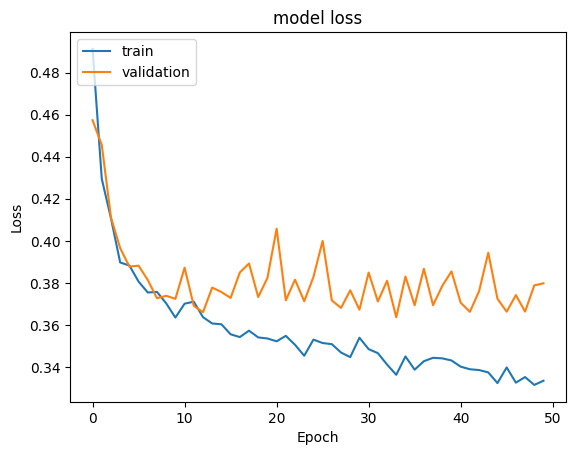

```python
#Plotting Train Loss vs Validation Loss
plt.plot(history_4.history['loss'])
plt.plot(history_4.history['val_loss'])
plt.title('model loss')
plt.ylabel('Loss')
plt.xlabel('Epoch')
plt.legend(['train', 'validation'], loc='upper left')
plt.show()
```

The graphs indicate a lot of noise especially in the validation dataset.

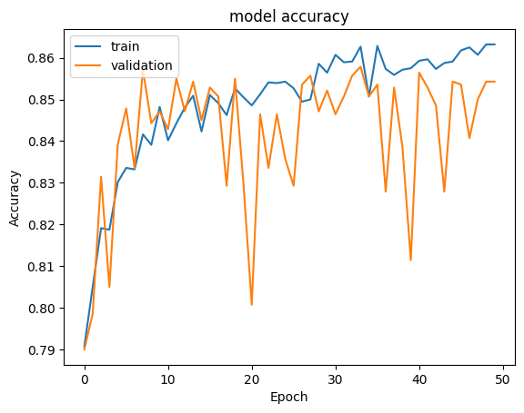

```python
#Plotting Train Accuracy vs Validation Accuracy
plt.plot(history_4.history['accuracy'])
plt.plot(history_4.history['val_accuracy'])
plt.title('model accuracy')
plt.ylabel('Accuracy')
plt.xlabel('Epoch')
plt.legend(['train', 'validation'], loc='upper left')
plt.show()
```

The graphs indicate a lot of noise in both the training as well as the validation datasets.

```python
score4 = estimator_v4.evaluate(X_test, y_test)
```

```
Best Threshold=0.155182, G-Mean=0.770
```

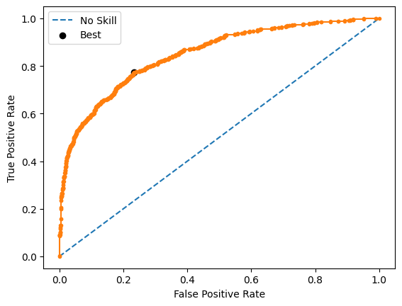

```python
# predict probabilities
yhat4 = estimator_v4.predict(X_test)
# keep probabilities for the positive outcome only
yhat4 = yhat4[:, 0]
# calculate roc curves
yhat4 = draw_roc_curve(yhat4)
```

[figure not shown]

```python
#Calculating the confusion matrix
from sklearn.metrics import confusion_matrix
cm5=confusion_matrix(y_test, yhat4)
labels = ['True Neg','False Pos','False Neg','True Pos']
categories = [ 'Staying back','Leaving the bank']
make_confusion_matrix(cm1,
                      group_names=labels,
                      categories=categories,
                      cmap='Blues')
```

Though the accuracy and loss graphs indicate high levels of noise, the False Negatives seem to have dropped when compared to Model 1 and Model 3. Model 2 continues to be the one with the least False Negatives.

```python
#Accuracy as per the classification report
from sklearn import metrics
cr5=metrics.classification_report(y_test,yhat4)
print(cr5)
```

```
              precision    recall  f1-score   support

           0       0.93      0.77      0.84      2389
           1       0.46      0.77      0.57       611

    accuracy                           0.77      3000
   macro avg       0.69      0.77      0.71      3000
weighted avg       0.83      0.77      0.79      3000
```

The recall here (0.77) is not the best we have seen so far - it however is better than Model3 (0.73) and lesser than Model 2 (0.80)

```python
recall4 =0.77
```

**Model Performance Comparison**

```python
# create dataframe using the loss and accuracy values calculated against the test data
comparison_frame_loss_and_accuracy = pd.DataFrame({"Model":["Loss", "Accuracy"],
                                        "Model1": score1,
                                        "Model2": score2,
                                        "Model3": score3,
                                        "Model4": score4}
                                )

comparison_frame_loss_and_accuracy
```

|  | Model | Model1 | Model2 | Model3 | Model4 |
| --- | --- | --- | --- | --- | --- |
| 0 | Loss | 0.357729 | 0.361244 | 0.356254 | 0.364882 |
| 1 | Accuracy | 0.856667 | 0.847333 | 0.857000 | 0.861667 |

```python
# create dataframe using the recall metrics
comparison_frame_recall = pd.DataFrame({"Model":["Recall"],
                                        "Model1": recall1,
                                        "Model2": recall2,
                                        "Model3": recall3,
                                        "Model4": recall4}
                                )

comparison_frame_recall
```

|  | Model | Model1 | Model2 | Model3 | Model4 |
| --- | --- | --- | --- | --- | --- |
| 0 | Recall | 0.45 | 0.8 | 0.73 | 0.77 |

**Model Performance Evaluation**

When it comes to loss and accuracy, all the 4 models yeilded approximately the same values - loss between 0.35-0.36 and accuracy between 0.85-0.86.

Taking the recall metric into consideration, Model2 is a clear winner by offering a recall value of 0.80. Model2 had good accuracy and loss graphs for both the training and validation datasets and it generalized well.

**Recommendation to the bank is to use Model2 for future analysis and identifying the customers that are most likely to leave the bank.**

**Conclusion**

We conducted Exploratory Data Analysis and noted the trends and patterns. We identified that

- Customers who purchased 3 or 4 products are more likely to leave the bank
- Customers in the age group of 40 to 60 are more likely to leave the bank
- Female customers seem to be leaving the bank more than their male counter parts.
- Customers based in Germany are exiting the bank compared to the customers based in France and Spain.
- Customers who are actively using the bank services are less likely to exit.
- The average balance of the attrited customers is slightly more than the average balance of the customers staying back with the bank.
- Data contains only 20% of customers who left the bank indicating an imbalance in the data.

We determined that recall is the metric of interest as we want minimal False Negatives.

We prepped the data for Model Building.

- Used OneHotEncoding for encoding the 2 categorical columns - Gender and Geography.
- We also used StandardScalar to ensure the features were in the same range.
- Dropped the 3 columns that do not contribute to the prediction power of the model.

We built 4 models with varying configurations. All the 4 models yeilded similar loss and accuracy values. However since recall is the metric of interest, we are recommending Model2 which produced the best recall value of 0.80.

Configuration of Model 2

- 3 layers - relu activation function for the hidden layer and sigmoid activation for the output layer.
- Adam Optimizer with a learning rate of 0.001
- Threshold of 0.16 was determined using the ROC-AUC curve
- Dropout(0.5)
- batch_size=128

**Recommendations**

Its obvious that customers who purchased 3 or 4 products are the ones who are leaving the bank. There is an urgent need to identify the product(s) that are causing the churn. Once identified, the bank needs to gather customer feedback on the products and build on enhancing the customer experience. Until this issue has been resolved, campaigns to get customers to buy more products might have to be placed on hold, with caution on the impact to the profits. The data tells us that more purchased products are contributing to the churn.

Customers from Germany seem to be churning more - we do not have enough data to analyze the underlying cause.

Older customers in the age group of 40 to 60 are leaving the bank. We need to invest in finding the root-cause here. Is the online experience discouraging older customers? Since we found out that younger customers tend to stay with the bank, we can channel our marketing towards attracting more younger customers.

Female customers are more likely to exit the bank compared to their male counter parts. This needs some investigation to get to the underlying cause.

Customers who actively use the bank services seem less likely to exit. Need to come up with creative ways to attract the customers to use the products regularly.

Giving incentives to provide customer feedback might help gather enough data to understand and analyze the loopholes.

50% of the customers are from France. The customers from Spain and Germany comprise of the remaining 50%. Bank could promote campaigns to attract more customers from Spain and Germany.

Bank can review customer profiles and issue credit cards to the customers that do not own a credit card. CreditScore and EstimatedSalary data can aid in customer profiling. Bank can offer promotions (lower interest rates etc) to retain the customers that are likely to leave.

We got enough data points to devise segmentation based marketing. Perhaps the bank could leverage this.

Overall, more data points can be added to the dataset to improve the prediction capabilities.